# PCA

Adi Sarid

July 2019

## Read the dataset

We’re returning to our Alchohol consumption data set (for details about this data set see `01-linear_regression_example1.Rmd`).

```r
alchohol <- read_csv("https://github.com/sarid-ins/statistical_learning_course/raw/master/datasets/alchohol_consumption/alchohol_consumption_ready.csv") %>%
  mutate(asia = ifelse(Continent_Name == "Asia", 1, 0),
         europe = ifelse(Continent_Name == "Europe", 1, 0),
         south_america = ifelse(Continent_Name == "South America", 1, 0),
         north_america = ifelse(Continent_Name == "North America", 1, 0),
         africa = ifelse(Continent_Name == "Africa", 1, 0))
```

## Are there any correlated variables?

One would expect that beer, spirit, and perhaps wine are correlated. If it’s indeed so - this indicates redundancy of some of the variables. Let’s check if this is the case.

```r
alchohol_cor <- alchohol %>%
  select_if(is.numeric) %>%
  cor()

knitr::kable(alchohol_cor)
```

|  | beer_servings | spirit_servings | wine_servings | total_litres_of_pure_alcohol | gdp2010 | Country_Number | asia | europe | south_america | north_america | africa |
| --- | --- | --- | --- | --- | --- | --- | --- | --- | --- | --- | --- |
| beer_servings | 1.0000000 | 0.4559662 | 0.5482755 | 0.8415194 | 0.3065209 | -0.0811407 | -0.3669701 | 0.4929013 | 0.1300745 | 0.1177973 | -0.2618891 |
| spirit_servings | 0.4559662 | 1.0000000 | 0.1880103 | 0.6588852 | 0.0625704 | -0.0846047 | -0.0542557 | 0.3387922 | 0.0941065 | 0.3010067 | -0.4475268 |
| wine_servings | 0.5482755 | 0.1880103 | 1.0000000 | 0.6807018 | 0.5000963 | -0.0608323 | -0.2643550 | 0.6224545 | 0.0471407 | -0.1223081 | -0.2730521 |
| total_litres_of_pure_alcohol | 0.8415194 | 0.6588852 | 0.6807018 | 1.0000000 | 0.3190473 | -0.0468499 | -0.3572133 | 0.5825188 | 0.0906617 | 0.0939972 | -0.2701774 |
| gdp2010 | 0.3065209 | 0.0625704 | 0.5000963 | 0.3190473 | 1.0000000 | 0.0450508 | -0.0562252 | 0.4898011 | -0.0807669 | -0.0531104 | -0.3174681 |
| Country_Number | -0.0811407 | -0.0846047 | -0.0608323 | -0.0468499 | 0.0450508 | 1.0000000 | 0.0216930 | -0.0289996 | -0.0711830 | -0.1069112 | 0.0649606 |
| asia | -0.3669701 | -0.0542557 | -0.2643550 | -0.3572133 | -0.0562252 | 0.0216930 | 1.0000000 | -0.3251662 | -0.1429035 | -0.1868851 | -0.3300511 |
| europe | 0.4929013 | 0.3387922 | 0.6224545 | 0.5825188 | 0.4898011 | -0.0289996 | -0.3251662 | 1.0000000 | -0.1545041 | -0.2020560 | -0.3568439 |
| south_america | 0.1300745 | 0.0941065 | 0.0471407 | 0.0906617 | -0.0807669 | -0.0711830 | -0.1429035 | -0.1545041 | 1.0000000 | -0.0887992 | -0.1568252 |
| north_america | 0.1177973 | 0.3010067 | -0.1223081 | 0.0939972 | -0.0531104 | -0.1069112 | -0.1868851 | -0.2020560 | -0.0887992 | 1.0000000 | -0.2050914 |
| africa | -0.2618891 | -0.4475268 | -0.2730521 | -0.2701774 | -0.3174681 | 0.0649606 | -0.3300511 | -0.3568439 | -0.1568252 | -0.2050914 | 1.0000000 |

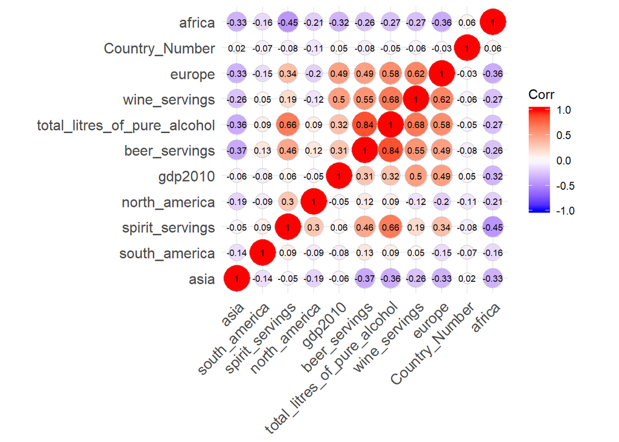

```r
#install.packages(ggcorrplot)
ggcorrplot::ggcorrplot(alchohol_cor, method = "circle",
                       lab = TRUE, hc.order = TRUE, lab_size = 2.5)
```

The variable which is mostly correlated is the `total_litres_of_pure_alcohol` (with the beer, spirit, and wine servings). **Why is that?**

Note that this is a variable we intentionally omitted from our previous linear regression analysis.

## Using PCA to reduce the number of features

The combination of continent, wine, spirit, and dgp per capita has a lot of medium to high correlations. Can this fact be leveraged to reduce the number of variables we are using?

We’ll return to the beer example in a short while, but first let’s explain about PCA.

### What is PCA?

PCA is an algebraic operation which decomposes the $X^TX$ matrix. It is an eigen-decomposition which helps us extract:

- The *eigen vectors* which have a unique propertie, and
- The *eigen values* which represent each eigen vector’s variance

We’re not going to delve deep into the technicalities of the math, but what’s important to understand is that:

- This decomposition **stretches and rotates** the original variables
- The new variables are sorted in a decreasing order of variance
- Selecting the first $v$ components gives us the best description of the existing data, in terms of capturing the maximum variance of the original variables with a subset of $v$ vars.

Here is an example for what PCA does on a simple example.

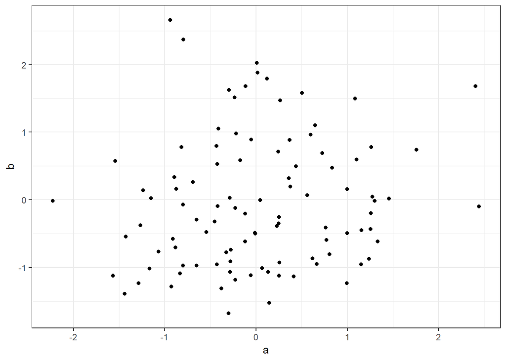

```r
set.seed(0)
randomized_data <- tibble(a = rnorm(100, 0, 1)) %>%
  mutate(b = rnorm(100, 0, 1)) %>%
  mutate(c = a + b + rnorm(100, 0, 0.6))

ggplot(randomized_data, aes(a, b)) +
  geom_point() +
  theme_bw()
```

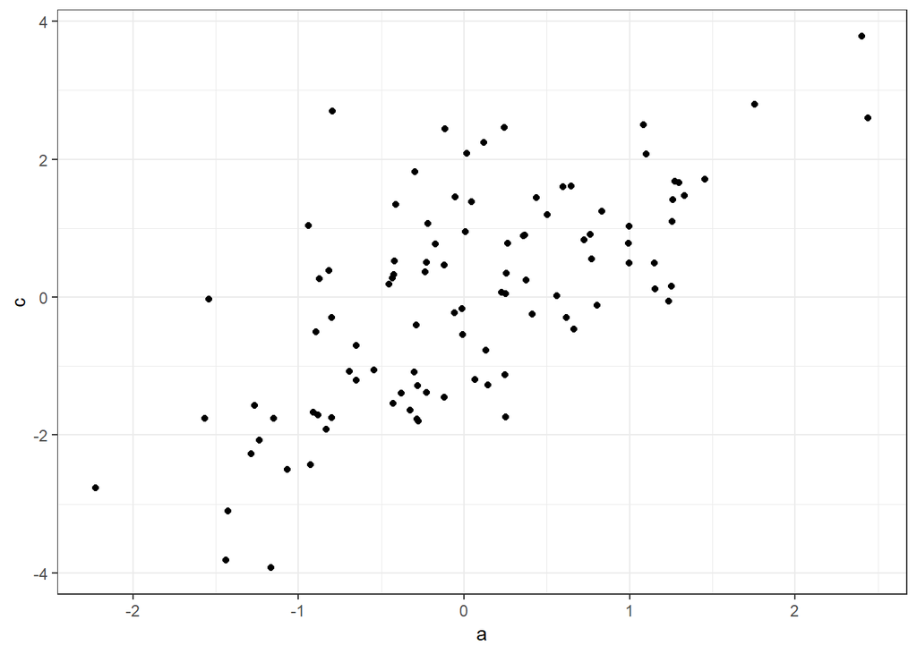

```r
ggplot(randomized_data, aes(a, c)) +
  geom_point() +
  theme_bw()
```

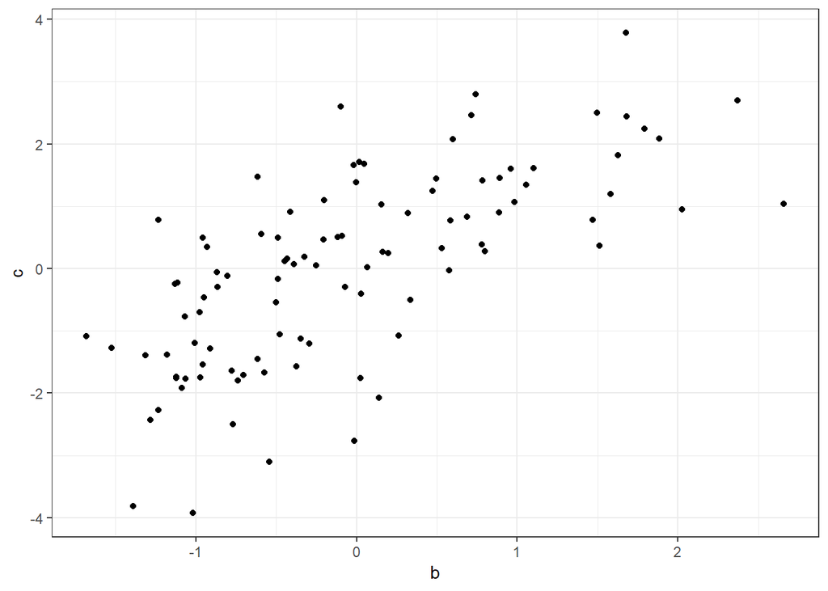

```r
ggplot(randomized_data, aes(b, c)) +
  geom_point() +
  theme_bw()
```

Now, we’ll run the PCA on the three variables and see what happens with the relationship of the new variables.

```r
pca_simple <- prcomp(randomized_data, center = TRUE, scale. = TRUE)

pca_simple$rotation
```

```
##          PC1        PC2        PC3
## a -0.5111851  0.7158680  0.4756288
## b -0.5209026 -0.6982280  0.4910581
## c -0.6836302 -0.0032653 -0.7298213
```

```r
summary(pca_simple)
```

```
## Importance of components:
##                           PC1    PC2     PC3
## Standard deviation     1.4265 0.9344 0.30334
## Proportion of Variance 0.6783 0.2910 0.03067
## Cumulative Proportion  0.6783 0.9693 1.00000
```

$$v_1 = -0.5a-0.52b-0.68c$$

The first two components of the PCA explain 97% of the variance in the data. The second component is given by:

$$v_2 = 0.72a - 0.7b -0.003c$$

We don’t really need three variables to describe our matrix! two are enough. We can retrieve the new matrix from the PCA object using `pca_simple$x`.

To perform the modification on a new data set, just use the `predict` function.

the actual values can be anything… predict will do the pca linear transformation on them.

```r
new_dataset <- tibble(a = 1:10, b = 2:11, c = 3:12)

predict(pca_simple, newdata = new_dataset)
```

```
##              PC1          PC2      PC3
##  [1,]  -2.989254 -0.692958912 0.158263
##  [2,]  -4.550369 -0.607214558 0.733399
##  [3,]  -6.111484 -0.521470204 1.308535
##  [4,]  -7.672599 -0.435725850 1.883671
##  [5,]  -9.233714 -0.349981496 2.458807
##  [6,] -10.794829 -0.264237142 3.033943
##  [7,] -12.355944 -0.178492789 3.609079
##  [8,] -13.917059 -0.092748435 4.184215
##  [9,] -15.478174 -0.007004081 4.759351
## [10,] -17.039289  0.078740273 5.334487
```

### Back to the beer example

We now illustrate how to perform the pca on the beer example. Note that I’m not including the variable which we are predicting on (the beer consumption).

Important:

1. PCA will work on numeric variables only, so we must prepare the data slightly better.
2. PCA doesn’t work with missing values.
3. If we don’t scale the data, we’ll get weird stuff (e.g. dgp2010 versus other variables).

```r
alchohol_pca <- alchohol %>%
  select(spirit_servings, wine_servings, gdp2010, asia:africa) %>%
  prcomp(center = TRUE, scale. = T)

summary(alchohol_pca)
```

```
## Importance of components:
##                           PC1    PC2    PC3    PC4     PC5     PC6     PC7
## Standard deviation     1.5842 1.2297 1.1364 1.0463 0.85331 0.64360 0.59984
## Proportion of Variance 0.3137 0.1890 0.1614 0.1368 0.09102 0.05178 0.04498
## Cumulative Proportion  0.3137 0.5028 0.6642 0.8010 0.89204 0.94382 0.98879
##                            PC8
## Standard deviation     0.29943
## Proportion of Variance 0.01121
## Cumulative Proportion  1.00000
```

To build a new model, we can do the following:

```r
new_alchohol_var <- predict(alchohol_pca,
        newdata = alchohol) %>%
  as.matrix() %>%
  as_tibble() %>%
  bind_cols(alchohol %>% select(beer_servings))

beer_pca5_lm <- lm(formula = beer_servings ~ . - PC8 - PC7 - PC6,
                   data = new_alchohol_var)
```

**What happens when we run a linear model with the original 8 variables versus a linear model based on all 8 components?**

[mentimeter](https://www.mentimeter.com/s/aa50b53604992e07d6f9fc6a91b8a7f5/402c59323ba7/edit)